# Probability and iterference

Tomasz Przechlewski  
email: t.plata-przechlewski@psw.kwidzyn.edu.pl  
affiliation: Powiślańska Szkoła Wyższa (Kwidzyn/Poland)

2024

# Probability

The outcome of a **random phenomenon** is determined by chance. A **random phenomenon** is described as a situation in which we know **what outcomes can occur**, but whose **precise outcome** is not certainly known.

Example: flipping coins, rolling dice

The **frequentist interpretation** (frequency) of the probability of an **event** occurring is defined as the **long-run fraction** of time that it would happen if the **random phenomenon** occurs over and over again under the same conditions.

Therefore, probabilities are always between 0 and 1

The frequentist interpretation of the probability is limited in application because many interesting random phenomena cannot be repeated over and over again, e.g., weather

Bayesian interpretation of Probability: interprets probability as a **subjective degree** of belief: For the same event, two separate people could have different viewpoints and so assign different probabilities

The **sample space** ($S$) of a random phenomenon is a set of all possible outcomes of the random phenomenon.

An **event** is is a subset of the sample space

Example: Flip a coin 3 times and record the side facing up each time.

Sample space S = { HHH, HHT, HTH, HTT, THH, THT, TTH, TTT }

Events: { all heads } = { HHH }

{ get one heads } = { HTT,THT,TTH }

{ get at least two heads } = { HHT,HTH,THH,HHH }

### Intersections, Unions, and Complements

events that are derived from other simpler events

The event that $A$ does not occur is called the **complement of** $A$ and is denoted $A^C$

The event that both $A$ and $B$ occur is called the **intersection** and is denoted $A ∩ B$

The event that either $A$ or $B$ occurs is called the **union** and is denoted $A ∪ B$

Complements, intersections, of events can be represented visually using **Venn diagrams**

**Disjoint (mutually exclusive) events** cannot be both true.

**Non-disjoint events** can be both true.

General Addition Rule:

$$P(A ∩ B) = P(A) + P(B) − P(A ∩
B)$$

sum of $A$ plus $B$ minus intersection of A and B

For disjoint events $P(A ∩ B) = 0$, so the above formula simplifies to

$$P(A ∩ B) = P(A) + P(B)$$

Complement Rule:

$$P(A) + P(A^c) = 1$$

**Conditional Probabilities**

Example: A card is drawn from a well-shuffled deck. What is the probability that the card drawn is a King?

$$P(\mathrm{King}) = 4 / 52 =
1/13$$

If the card drawn is known to be a face card (J, Q, K) , what is the probability that it is a K? $4/12 = 1/3$

Given two events $A$ and $B$. We denote the probability of event $A$ happens given that event $B$ is known to happen as $P(A|B)$, (read: A given B)

$$P(A|B) = P(A ∩ B)/P(B)$$

if P(A|B) = P(A) then the events A and B are said to be independent. (Giving B doesn’t tell us anything about A.)

When A and B are independent

P(A and B) = P(A) × P(B)

More generally:

$$P(A_1 ∩ \cdots ∩ A_k ) = P(A_1 ) ×
\ldots × P(A_k )$$

if $A_1, \cdots, A_k$ are independent.

# Random variables

The outcome of a **random variable** is determined by chance.

The **probability distribution** determines the probability of the outcomes of a random variable.

There are two types of random variables, **discrete** and **continuous**.

A **discrete random variable** consists of integers only.

A **continuous random variable** can take an infinite number of values between any two values.

The **probability distribution** for a discrete random variable is called a **discrete probability distribution** and is denoted as $P(x) = P(X=x)$.

$0 \leq P(x) \leq 1$ for any $x$

$\sum_x P(x) = 1$

**Cumulative distribution function** (CDF)

$$F(x_0) = P(X \leq x_0)$$

**Expected value** (think mean), $E[X]$, of a discrete random variable $X$ is defined as

$$E[X]= \mu = \sum_x x P(x)$$

The expectation of the squared deviations about the mean, $(X - E[X])^2$, is called the **variance**, denoted as $D^2[X]$ and given by

$$D^2[X] = \sigma^2 = \mathrm{Var} (X) =
E[(X - E[X])^2 ] = E[X^2] - (E[X])^2$$

### Continuous random variable

Exact values in continuous distributions have a **zero probability** Why?

Let assume that the probability of continuous variable $X$ over range $[a,b]$ is non-zero, but we can infinitely divide this range. So as the number of divisions goes to infinity, the range width goes to zero, as well as the probability of the variable assuming a value from this (shrinking) interval is **zero**.

The probability distribution for a continuous random variable is called a **probability density function** (pdf).

Let $X$ be a continuous random variable, and let $x$ be any number lying in the range of values for the random variable. The probability density function, $f(x)$, of the random variable is a function with the following properties:

1. $f (x)> 0$ for all values of $x$.
2. The area under the probability density function, $f(x)$, over all values of the random variable, X within its range, is equal to 1.0.
3. Let a and b be two possible values of random variable X. The probability that X lies between a and b is:

$$P(a \leq X \leq b) = \int_a^b
f(x)dx$$

This equals the area under the probability density function between $[a,b]$.

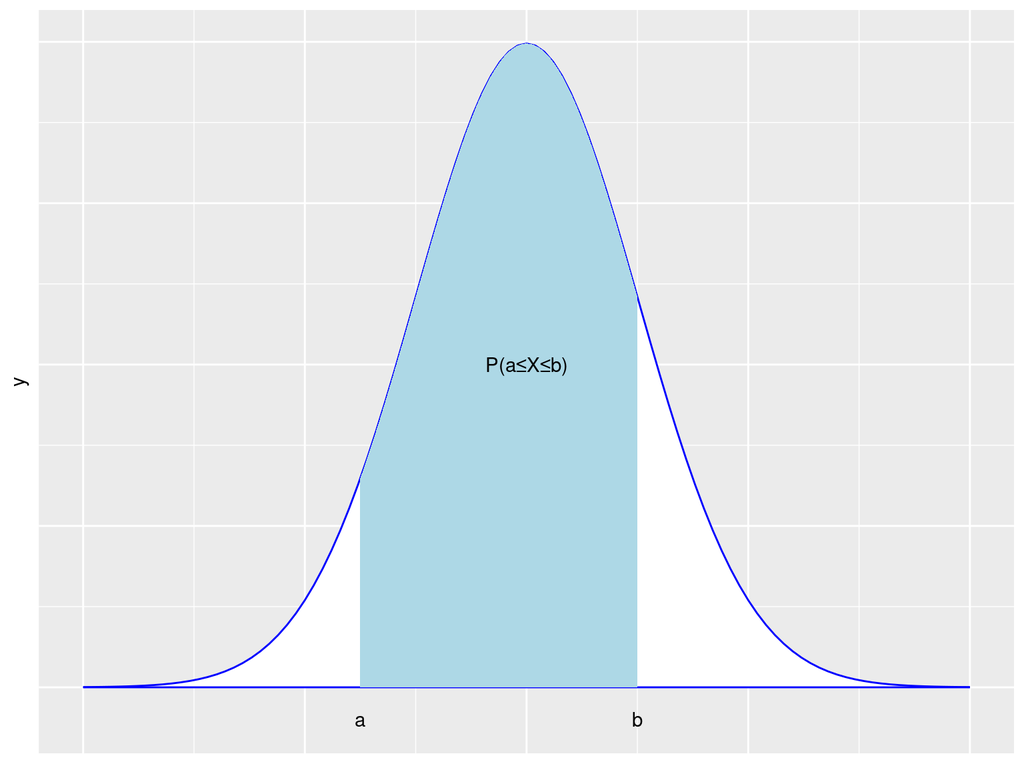

Cumulative distribution function (CDF)

The cumulative distribution function, $F(x)$ for a continous random variable $X$ expresses the probability that $X$ does note exceed the value of $x$:

$$F(x) = P(X \leq x) = \int_{-\infty}^x
f(x) dx$$

**Expected value** (think mean), $E[X]$, of a continuous random variable $X$ is defined as

$$E[X]= \int_{-\infty}^\infty x
f(x)dx$$

**Variance**, $D^2[X]$, of a continuous random variable $X$ is defined as

$$\mathrm{Var}(X) = \sigma^2 =
\int_{-\infty}^\infty (x - \mu)^2 f(x)dx$$

### Continuous distribution functions

(next slide)

# Normal DF

A normal distribution is characterized by its mean $μ$ and its **standard deviation** $σ$; it is denoted by $N(μ, σ^2)$. The normal distribution has the PDF

$$f(x) = \frac{1}{\sqrt{2\pi \sigma} }
\exp^{ -\frac{x -\mu^2}{2\sigma^2} }$$

$N(0, 1)$ is called **standard normal distribution** (denoted by $Z$);

$$Z = \frac{X - \mu}{\sigma} \sim N(0,
1)$$

Note: $X\sim N$ reads as **X is distributed as N**

### R

```
## dnorm(x, mean=0, sd=1) -- density
## pnorm(q, mean=0, sd=1) -- distribution function,
## qnorm(p, mean=0, sd=1) -- quantile function
dnorm(x=2)
pnorm(x=c(-2, 2), mean=1, sd=0.2)
## rnorm(n, mean=0, sd=1) -- generates random deviates.
rnorm(1000, mean=5, sd=2)

## compute probabilities [-2,1], [1,2], [0,5,1.5]
lower <- c( -2, 1, 0.5)
upper <- c( 1, 2, 1.5)
lower.p <- pnorm(lower, mean=3, sd=1)
upper.p <- pnorm(lower, mean=3, sd=1)
p <- upper.p - lower.p

## generate 5000 random normal numbers
## data.frame() because of subsequent ggplot
s <- data.frame(v=rnorm(n=5000, mean=5, sd=2))

library("ggplot2")
ggplot(s, aes(x=v)) +
  geom_histogram(binwidth= .1, alpha=.5, fill="steelblue")
```

# Chi-squared DF

The sum of $M$ squared **independent standard normal distributed** random variables follows a chi-squared (or $\chi$-squared) distribution with  
$M$ degrees of freedom:

$$Z_1^2 + \ldots + Z_M^2 = \sum_{m=1}^M
Z_m^2 \sim \chi^2_M$$

A $χ^2$ distributed random variable with $M$ degrees of freedom has expected value $M$, mode at $M − 2$ (for $M ≥ 2$) and variance $2M$

R: `dchisq`

# t-Student DF

Let $Z$ be a standard normal variate, $W$ a $\chi^2_M$ variate and further assume that $Z$ and $W$ are independent. Then it holds that

$$\frac{Z}{\sqrt{W/M}} \sim
t_M$$

$t$ follows a t-Student distribution with M degrees of freedom.

$t$ distributions are symmetric, bell-shaped and look similar to a normal distribution, especially when $M$ is large.

For a sufficiently large  
$M$, the $t_M$ distribution can be approximated by the standard normal distribution. This approximation works reasonably well for  
$M ≥ 30$

# F DF

Let $W \sim \chi^2_M$ and $V \sim \chi^2_n$; then

$$\frac{W/M}{V/n} \sim
F_{M,n}$$

$F$ follows $F$ distribution with numerator degrees of freedom  
$M$ and denominator degrees of freedom $n$.

# Central limit theorem

Let $X_1, X_2, \ldots, X_n$ be a set of $n$ identical independent random variables (iid) mean $\mu$, and variance $\sigma_2$. Let $\bar X$ is a sample mean. As $n$ becomes large, the central limit theorem states that the distribution of

$$Z = \frac{\bar X -
\mu}{\frac{\sigma}{\sqrt{n}}} \sim N(0,1)$$

# Estimation

**Estimators** are functions of sample data drawn from an unknown population.

**Estimates** are numeric values computed by estimators based on the sample data.

**Estimators** are **random variables** because they are functions of random data (thus have a certain distribution). Estimates are **nonrandom numbers**.

Suppose we are interested in **estimation** of $μ_Y$, the mean of some variable $Y$. Due to time/financial constrains we are unable to calculate exact value of $μ_Y$.

Instead we can draw a random sample of size $n$ observations and **estimate** $\mu_Y$ using the following function (ie. estimator, as estimator are functions):

$$\bar Y = \frac{1}{n} \sum_{i=1}^n
Y_i$$

which is of course **sample mean**; we are free to use other functions of course, namely:

$$Y^f = \frac{Y_\max -
Y_{\min}}{2}$$

To be usefull **estimator** have to demonstrate three desirable properties: **unbiasedness**, **consistency** and **efficiency**.

# Estimator properties

### Unbiasedness

If the mean of the sampling distribution of some estimator  
$\hat μ_Y$ for the population mean $μ_Y$ equals $μ_Y$

$$E(\hat μ_Y) = μ_Y$$

the estimator is **unbiased** for $\mu_Y$. The bias of $\hat \mu_Y$ then is zero. If bias is non-zero such an estimator is called **biased**

The above can be generalized for any parameter $p$, not only mean: the estimator $\hat p$ of the parameter $p$ is unbiased if $E(\hat p) = p$

### Consistency

Variability/spread of the estimator  
$\hat μ_Y$ decrease as the sample size $n$ grows.

$$P(|\hat μ_Y - μ_Y | > \epsilon ) =
0$$

for any $\epsilon$ (even very small one) and $n \to \infty$. The above less formally: the probability that the **estimate** $\hat \mu_Y$ falls outside a small interval around the true value of $\mu_Y$ get to zero as sample size $n$ grows.

To **increase accuracy**, the sample size $n$ must be increased or **any level of accuracy is a matter of sample size.**

### Efficiency

Finally suppose, we have two estimators $\hat \mu_Y$ and $\ddot\mu_Y$ and for some given sample size $n$ it holds that

$$E(\hat\mu_Y) = E(\ddot\mu_Y) =
\mu_Y$$

but

$$\mathrm{var}(\hat\mu_Y) <
\mathrm{var}(\ddot\mu_Y)$$

then we say that $\hat\mu_Y$ is **more efficient** than $\ddot\mu_Y$. We prefer of course **more efficient** estimators as they **on the average** provide more precise estimates.

# Point and Interval estimation

### Point estimation

In **point estimation**, a single value, known as the **point estimate**, is calculated (based on estimator formula) as the best guess for the parameter.

Example: Point estimator of population mean $\mu$ is sample mean $\bar X$

Confidence Interval Estimator

A **confidence interval** estimator for a population parameter is a rule for determining (based on sample information) an interval that is likely to include the parameter. The corresponding estimate is called a confidence interval estimate.

Let $\theta$ be an unknown parameter. Suppose that on the basis of sample information, random variables $A$ and $B$ are found such that $P ( A < \theta < B ) = 1 - \alpha$, where $\alpha$ is any number between 0 and 1. If the specific sample values of $A$ and $B$ are $a$ and $b$, then the interval from $a$ to $b$ is called a $100( 1 - \alpha)$% confidence interval of $\theta$. The quantity $100 (1 - \alpha)$% is called the confidence level of the interval. If the population is repeatedly sampled a large number of times, the true value of the parameter $\theta$ will be covered by $100( 1 - \alpha)$% of intervals calculated this way. The confidence interval calculated in this manner is written as $a < u < b$, with $100 (1 - \alpha)$% confidence.

### Confidence Intervals for the population mean

Population with unknown mean $\mu$ and known variance $\sigma^2$.

Let $x_1, x_2 ,\ldots, x_n$ be a random sample of $n$ observations from a normally distributed population with unknown mean $\mu$ and known variance $\sigma^2$. Suppose that we want a $100(1 - \alpha)$% confidence interval of the population mean

We know that

$$Z = \frac{\bar x -
\mu}{\frac{\sigma}{\sqrt{n}}} \sim N(0,1)$$

moreover $z_{\alpha/2}$ is the value from the standard normal distribution such that the upper tail probability is $\alpha/2$. Thus

$$\begin{align}
1 - \alpha = P (-z_{\alpha/2} < Z < z_{\alpha/2}) \nonumber\\
= P(-z_{\alpha/2} < \frac{\bar x -\mu}{\frac{\sigma}{\sqrt{n}}} <
z_{\alpha/2} ) \nonumber \\
= P(-z_{\alpha/2} \frac{\sigma}{\sqrt{n}} < \bar x -\mu <
z_{\alpha/2} \frac{\sigma}{\sqrt{n}} ) \nonumber \\
= P(\bar x -z_{\alpha/2} \frac{\sigma}{\sqrt{n}} < \mu <
\bar x + z_{\alpha/2} \frac{\sigma}{\sqrt{n}} ) \nonumber
\end{align}$$

For a 95% confidence level it follows that

$$P(\bar x - 1.96 \frac{\sigma}{\sqrt{n}}
< \mu < \bar x + 1.96 \frac{\sigma}{\sqrt{n}} ) =
0.95$$

or, generally for $100(1 - \alpha)$% confidence interval

$$CI = \bar x \pm z_{\alpha/2}
\frac{\sigma}{\sqrt{n}}$$

### Population with unknown mean $\mu$ and **unknown** variance $\sigma^2$.

Reminder: Student’s $t$ Distribution Given a random sample of $n$ observations, with mean $\bar x$ and standard deviation $s$, from a normally distributed population with mean $\mu$, the random variable $t$ follows the Student’s $t$ distribution with $n - 1$ degrees of freedom and is given by

$$t= \frac{\bar x -
\mu}{s/\sqrt{n}}$$

So, confidence interval for the population mean with unknown variance, is given by

$$CI = \bar x \pm t_{n-1, \alpha/2}
\frac{s}{\sqrt{n}}$$

# Confidence interval for population proportion

Consider a random experiment that can give rise to just two possible mutually exclusive and collectively exhaustive outcomes, which for convenience we label “success” and “failure.” Let $P$ denote the probability of success, and, the probability of failure $1 - P$. Then, define the random variable $X$ so that $X$ takes the value $1$ if the outcome of the experiment is success and $0$ otherwise. The probability distribution of this random variable is then $P(0)= 1 - P$ and $P(1) = P$

This distribution is known as the Bernoulli distribution (discrete).

Expected value of this distribution is $\mu = P$; variance $\sigma^2 = P(1-P)$

Let $\hat p$ be the sample proportion of successes in a random sample from a population with proportion of success $P$.

The sampling distribution of $\hat p$ has mean $P$

$$E[\hat p] = P$$

The sampling distribution of $\hat p$ has standard deviation

$$\sigma_{\hat p} =
\sqrt{\frac{P(1-P)}{n}}$$

For large $n$ (large means: $nP(1-P)>5$):

$$Z=\frac{\hat p - P}{ \sigma_{\hat p} }
\sim N(0,1)$$

For large $n$ (large means: $nP(1-P)>5$):

$$\sqrt{\frac{P(1-P)}{n}} \approx
\sqrt{\frac{\hat p(1- \hat p)}{n}}$$

Hence (for large n)

$$Z=\frac{\hat p - P}{ \sqrt{\hat p (1-
\hat p)/n } } \sim N(0,1)$$

This can be used to construct CI

$$CI = \hat p \pm z_{\alpha/2} \sqrt{\hat
p (1-\hat p)/n}$$

# Hypothesis testing

Hypotheses are simple questions that can be answered by ‘yes’ or ‘no’. There are two different hypotheses:

The **null hypothesis**, denoted by $H_0$. The test is designed to assess the strength of the evidence **against** the null hypothesis (NOT strength of the evidence **for** it; it is important)

Usually the $H_0$ claims: no effect, zero difference or similar

The **alternative hypothesis**, denoted by  
$H_1$, the hypothesis that is thought to hold if the null hypothesis is rejected. Actually the claim we are trying to prove is $H_1$ not $H_0$

The null hypothesis that the population mean of  
$Y$ (ie $\mu_Y$) equals the value $m_Y$ is written as:

$$H_0: \mu_Y = m_Y$$

Often the alternative hypothesis is chosen such that it is the most general one:

$$H_1: \mu_Y \not= m_Y$$

This is called a **two-sided alternative** hypothesis.

### Test statistic

The decision is based **test statistic** (statistic is a function of a sample, or **any number computed from sample data**).

The test statistic is usually based on a statistic that estimates the **parameter** that appears in the hypotheses (or some function of this parameter)

In the case of $\mu_Y$ **test statistic** can be the following:

$$\frac{\bar Y -
\mu_Y}{\frac{\sigma}{\sqrt{n}}} \sim Z$$

where $Z\sim N(0,1)$ of course. We do not know $\mu_Y$ but we can substitute $m_Y$ and thus compute $Z$-value, denoted as $\hat Z$.

For obvious reason we expect **small** value of $\hat Z$ if $H_0$ is true (why?); the bigger $\hat Z$, the greater our suspicions that $H_0$ is wrong.

So, why we can obtain **big** $\hat Z$? For exactly two reasons:

1. We were unlucky and we obtained a very untypical sample
2. The $H_0$ is untrue

We (as statisticians) always choose 2; sometimes **making an error**. The error that we reject $H_0$ because $\hat Z$ is too big, but in fact $H_0$ is true (and we just have obtained **untypical** sample) is called **type one error** (or **type I error**).

We can choose arbitrarily some (small) probability of that **type I error**. This probability is called **significance level** and denoted as $\alpha$ (alpha).

More precisely, **significance level**, denoted by $𝛼$, is the probability of rejecting the null hypothesis, given that the null hypothesis is true.

We can now compute $Z_C$ such as:

$$P(|\hat Z| > Z_C) =
\alpha$$

It is the probability that $\hat Z$ takes value as extreme and more extrame than $Z_C$; and this probability is equal to **significance level**. So if we got $Z_C$, then the observed outcome is within **impossible event margin** (at $\alpha$ significance level). This means that we reject $H_0$.

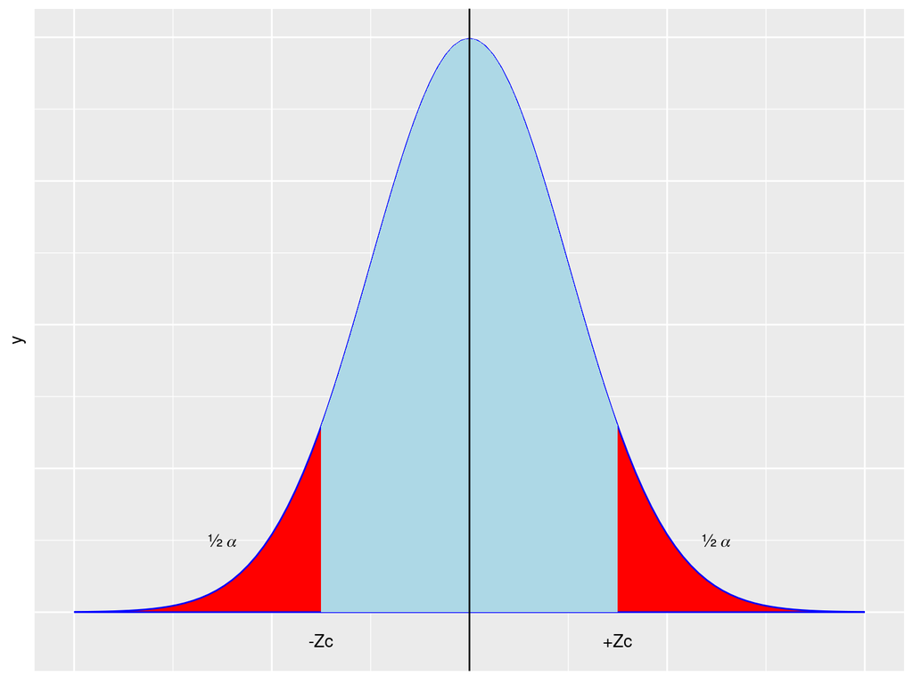

### p-value

There is simpler rule to reject or fail to reject $H_0$. Instead of comparing $\hat Z$ vs $Z_C$ one can compute the probability that $P(|Z| > \hat Z)$ (depicted dark red at the picture.) If this probability is equal or less then $\alpha$ one can reject $H_0$ (why?)

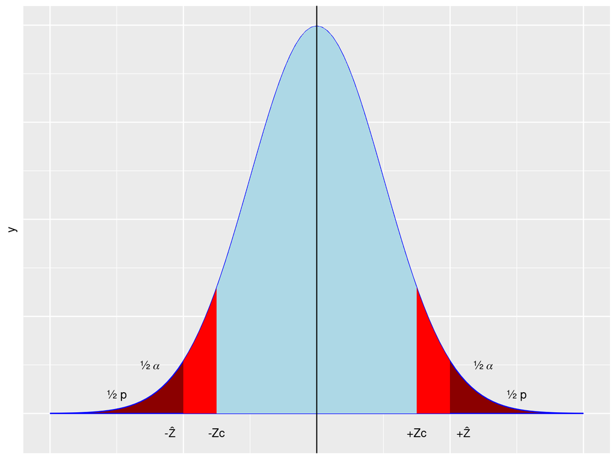

P-value (or p) is routinely printed by all computer programs. If your program fails to provide p, change the program.

https://statisticsbyjim.com/hypothesis-testing/failing-reject-null-hypothesis/